# Reproduction: Re-examining the testing effect as a learning strategy

- Show All Code
- Hide All Code
- View Source

Mayrhofer, Kuhbandner & Frischholz (2023), *Frontiers in Psychology*, 14:1258359

Author

Computational reproduction in R

Published

June 3, 2026

```r
library(haven)
library(dplyr)
library(tidyr)
library(ggplot2)
library(knitr)

# Partial eta-squared for a one-way (or factorial) aov object
eta_p <- function(model, term) {
  ss <- summary(model)[[1]][["Sum Sq"]]
  rn <- trimws(rownames(summary(model)[[1]]))
  ss_e <- ss[rn == term]
  ss_r <- ss[rn == "Residuals"]
  ss_e / (ss_e + ss_r)
}

# Pretty p-value
fp <- function(p) ifelse(p < 0.001, "< .001", sub("^0", "", sprintf("%.3f", p)))
```

# 1 Overview

This document reproduces the statistical analyses reported in Mayrhofer, Kuhbandner & Frischholz (2023), *“Re-examining the testing effect as a learning strategy: the advantage of retrieval practice over concept mapping as a methodological artifact”* ([doi:10.3389/fpsyg.2023.1258359](https://doi.org/10.3389/fpsyg.2023.1258359)).

The raw data (a single SPSS file, `Data.sav`) was downloaded from the study’s OSF repository at https://osf.io/fj95g/. The study used a one-by-four between-subjects design with four learning-strategy conditions:

| Code (data) | Label in paper | Description |
| --- | --- | --- |
| `RP+AM+RI` | RP + AM + AI | Retrieval practice + additional memorization + additional instruction (Karpicke & Blunt’s “retrieval practice”) |
| `CM-AM-RI` | CM − AM − AI | Concept mapping, no additional memorization, no additional instruction (Karpicke & Blunt’s “concept mapping”) |
| `CM-AM+RI` | CM − AM + AI | Concept mapping + instruction “incorporate as much as possible” |
| `CM+AM+RI` | CM + AM + AI | Concept mapping + additional memorization + instruction |

(The data file abbreviates the additional **i**nstruction confounder as `RI`; the paper calls it `AI`. They denote the same factor.)

The central claim of the paper: the apparent advantage of retrieval practice over concept mapping is a **methodological artifact**. It is driven by extra memorization time (and an instruction to “recall as much as possible”) that was present only in the retrieval-practice condition — not by retrieval practice per se.

```r
d <- read_sav("Data.sav")
d$cond <- factor(as_factor(d$condition),
                 levels = c("RP+AM+RI", "CM-AM-RI", "CM-AM+RI", "CM+AM+RI"))
dim(d)
```

```
[1] 230  34
```

# 2 Scoring the memory test

The final test comprised 16 questions split into **14 verbatim** and **2 inference** questions (Section 2.2 of the paper). Verbatim questions are worth a maximum of **21** scoring points; inference questions a maximum of **4** points. In the data file each question (or sub-part) is scored 0 / 0.5 / 1.

The mapping of data columns to the paper’s point scheme:

- **Verbatim (max 21):** `Q1`–`Q11` and `Q13` (twelve 1-point items) + `Q12` (`Prince_William_Sound` + `Alaska`, the 2-point item) + `Q14` (`clams, crabs, fish, squid, octopus, seaurchins, abalones`, the 7-point item). → 12 + 2 + 7 = **21**.
- **Inference (max 4):** `Q15` (`protection` + `more_invertebrates`) + `Q16` (`fur` + `hunting`), each question worth 2 points. → **4**.

Performance is expressed as the **proportion of the maximum possible score**, exactly as in the paper’s Figure 3.

```r
verb_cols <- c("Q1","Q2","Q3","Q4","Q5","Q6","Q7","Q8","Q9","Q10","Q11",
               "Q12_Prince_William_Sound","Q12_Alaska","Q13",
               "Q14_clams","Q14_crabs","Q14_fish","Q14_squid",
               "Q14_octopus","Q14_seaurchins","Q14_abalones")
inf_cols  <- c("Q15_protection","Q15_more_invertebrates","Q16_fur","Q16_hunting")

d$verb_score <- rowSums(sapply(d[verb_cols], as.numeric))
d$inf_score  <- rowSums(sapply(d[inf_cols],  as.numeric))
d$verbatim   <- d$verb_score / 21   # proportion correct, verbatim
d$inference  <- d$inf_score  / 4    # proportion correct, inference

c(max_verbatim_points = max(d$verb_score), max_inference_points = max(d$inf_score))
```

```
 max_verbatim_points max_inference_points
                  21                    4
```

# 3 Sample

```r
n_total <- nrow(d)
gender_tab <- table(as_factor(d$gender))
data.frame(
  Statistic = c("N (final sample)", "Mean age (SD)", "No age reported",
                "Female", "Male", "Other / no gender (incl. missing)"),
  Value = c(
    n_total,
    sprintf("%.2f (%.2f)", mean(d$age, na.rm = TRUE), sd(d$age, na.rm = TRUE)),
    sum(is.na(d$age)),
    sprintf("%d (%.1f%%)", gender_tab[["f"]], 100*gender_tab[["f"]]/n_total),
    sprintf("%d (%.1f%%)", gender_tab[["m"]], 100*gender_tab[["m"]]/n_total),
    sprintf("%d (%.1f%%)", gender_tab[["o"]] + sum(is.na(d$gender)),
            100*(gender_tab[["o"]] + sum(is.na(d$gender)))/n_total)
  )
)
```

```
                          Statistic        Value
1                  N (final sample)          230
2                     Mean age (SD) 21.65 (4.77)
3                   No age reported            3
4                            Female  178 (77.4%)
5                              Male   48 (20.9%)
6 Other / no gender (incl. missing)     4 (1.7%)
```

```r
table(d$cond)
```

```
RP+AM+RI CM-AM-RI CM-AM+RI CM+AM+RI
      55       58       58       59
```

Matches the paper: *N* = 230, *M*<sub>age</sub> = 21.65 (*SD* = 4.77), 3 stated no age, 178 (77.4%) female, 48 (20.9%) male. Cell sizes are 55 / 58 / 58 / 59.

**Note**

The paper reports “6 (1.7%)” indicated other or no gender. The data contain 1 participant coded “other” plus 3 with missing gender = 4 participants. Note 4/230 = 1.7%, which matches the reported percentage — so the count “6” appears to be a typographical slip; the percentage is correct.

# 4 Descriptive statistics

```r
desc <- d %>%
  group_by(Condition = cond) %>%
  summarise(
    n = n(),
    `Verbatim M`  = mean(verbatim),  `Verbatim SD`  = sd(verbatim),
    `Inference M` = mean(inference), `Inference SD` = sd(inference),
    `JoL M` = mean(JoL), `JoL SD` = sd(JoL),
    .groups = "drop"
  )
kable(desc, digits = 2,
      caption = "Means and SDs by condition. Compare to paper Section 3 / Figure 3.")
```

Means and SDs by condition. Compare to paper Section 3 / Figure 3.

| Condition | n | Verbatim M | Verbatim SD | Inference M | Inference SD | JoL M | JoL SD |
| --- | --- | --- | --- | --- | --- | --- | --- |
| RP+AM+RI | 55 | 0.73 | 0.15 | 0.71 | 0.19 | 44.18 | 16.29 |
| CM-AM-RI | 58 | 0.59 | 0.20 | 0.75 | 0.21 | 54.40 | 16.86 |
| CM-AM+RI | 58 | 0.62 | 0.18 | 0.81 | 0.15 | 59.14 | 17.09 |
| CM+AM+RI | 59 | 0.70 | 0.16 | 0.79 | 0.21 | 58.64 | 14.68 |

The verbatim and inference means/SDs reproduce the paper to two decimals: verbatim **.73 / .59 / .62 / .70** and inference **.71 / .75 / .81 / .79**.

# 5 Verbatim questions

## 5.1 One-way ANOVA

> Paper: *F*(3, 226) = 8.33, *p* < 0.001, η²<sub>p</sub> = 0.10.

```r
m_verb <- aov(verbatim ~ cond, data = d)
summary(m_verb)
```

```
             Df Sum Sq Mean Sq F value   Pr(>F)
cond          3  0.755 0.25160   8.335 2.79e-05 ***
Residuals   226  6.822 0.03019
---
Signif. codes:  0 '***' 0.001 '**' 0.01 '*' 0.05 '.' 0.1 ' ' 1
```

```r
cat(sprintf("partial eta-squared = %.3f\n", eta_p(m_verb, "cond")))
```

```
partial eta-squared = 0.100
```

## 5.2 Tukey HSD post-hoc comparisons

The paper reports (Section 3): RP + AM + AI > CM − AM − AI (*p* < 0.001); RP + AM + AI vs CM + AM + AI n.s. (*p* = 0.854); CM − AM + AI outperformed by both RP + AM + AI (*p* = 0.004) and CM + AM + AI (*p* = 0.041); CM − AM − AI vs CM + AM + AI (*p* = 0.003); CM − AM − AI vs CM − AM + AI n.s. (*p* = 0.842).

```r
tk <- TukeyHSD(m_verb)$cond
kable(round(tk, 4), caption = "Tukey HSD, verbatim questions")
```

Tukey HSD, verbatim questions

|  | diff | lwr | upr | p adj |
| --- | --- | --- | --- | --- |
| CM-AM-RI-RP+AM+RI | -0.1383 | -0.2230 | -0.0537 | 0.0002 |
| CM-AM+RI-RP+AM+RI | -0.1117 | -0.1963 | -0.0270 | 0.0042 |
| CM+AM+RI-RP+AM+RI | -0.0261 | -0.1104 | 0.0582 | 0.8536 |
| CM-AM+RI-CM-AM-RI | 0.0267 | -0.0568 | 0.1102 | 0.8416 |
| CM+AM+RI-CM-AM-RI | 0.1122 | 0.0291 | 0.1954 | 0.0032 |
| CM+AM+RI-CM-AM+RI | 0.0856 | 0.0024 | 0.1687 | 0.0410 |

All six comparisons reproduce the paper (e.g. RP vs CM−AM−AI *p* = .0002; RP vs CM+AM+AI *p* = .854; RP vs CM−AM+AI *p* = .004; CM+AM+AI vs CM−AM−AI *p* = .003; CM+AM+AI vs CM−AM+AI *p* = .041; CM−AM+AI vs CM−AM−AI *p* = .842).

**Important**

## 5.3 Outlier-removed ANOVA

> Paper footnote 4: one extreme outlier in CM + AM + AI (> 3 *SD* below the cell mean). Removing it: *F*(3, 225) = 9.17, *p* < 0.001, η²<sub>p</sub> = 0.11; post-hoc CM + AM + AI vs RP + AM + AI *p* = 0.950; vs CM − AM + AI *p* = 0.017; vs CM − AM − AI *p* < 0.001.

```r
g <- d$verbatim[d$cond == "CM+AM+RI"]
thr <- mean(g) - 3 * sd(g)
d_no <- d[!(d$cond == "CM+AM+RI" & d$verbatim < thr), ]
cat(sprintf("Removed %d outlier (verbatim = %.2f, threshold = %.3f)\n",
            sum(d$cond == "CM+AM+RI" & d$verbatim < thr),
            g[g < thr], thr))
```

```
Removed 1 outlier (verbatim = 0.19, threshold = 0.219)
```

```r
m_verb2 <- aov(verbatim ~ cond, data = d_no)
summary(m_verb2)
```

```
             Df Sum Sq Mean Sq F value   Pr(>F)
cond          3  0.801 0.26711    9.17 9.49e-06 ***
Residuals   225  6.554 0.02913
---
Signif. codes:  0 '***' 0.001 '**' 0.01 '*' 0.05 '.' 0.1 ' ' 1
```

```r
cat(sprintf("partial eta-squared = %.3f\n", eta_p(m_verb2, "cond")))
```

```
partial eta-squared = 0.109
```

```r
round(TukeyHSD(m_verb2)$cond[c("CM+AM+RI-RP+AM+RI",
                               "CM+AM+RI-CM-AM+RI",
                               "CM+AM+RI-CM-AM-RI"), "p adj"], 4)
```

```
CM+AM+RI-RP+AM+RI CM+AM+RI-CM-AM+RI CM+AM+RI-CM-AM-RI
           0.9499            0.0168            0.0010
```

The *F* (9.17), η²<sub>p</sub> (.11) and all three post-hoc *p*-values (.950, .017, < .001) reproduce the footnote exactly.

**Note**

The footnote states the outlier-removed mean for CM + AM + AI is *M* = 0.75. The recomputed mean is **0.71**. Because removing a single low value (0.19) from a cell of 59 can only nudge a mean of 0.70 upward slightly, 0.75 appears to be a typo in the paper. The exact match of the *F*-statistic (9.17) confirms the same data point was removed.

# 6 Inference questions

## 6.1 One-way ANOVA

> Paper: *F*(3, 226) = 2.99, *p* = 0.032, η²<sub>p</sub> = 0.038.

```r
m_inf <- aov(inference ~ cond, data = d)
summary(m_inf)
```

```
             Df Sum Sq Mean Sq F value Pr(>F)
cond          3  0.327 0.10891   2.987  0.032 *
Residuals   226  8.240 0.03646
---
Signif. codes:  0 '***' 0.001 '**' 0.01 '*' 0.05 '.' 0.1 ' ' 1
```

```r
cat(sprintf("partial eta-squared = %.3f\n", eta_p(m_inf, "cond")))
```

```
partial eta-squared = 0.038
```

## 6.2 Tukey HSD post-hoc comparisons

> Paper: the only statistically significant difference is RP + AM + AI vs CM − AM + AI (*p* = 0.038); all others n.s.

```r
kable(round(TukeyHSD(m_inf)$cond, 4), caption = "Tukey HSD, inference questions")
```

Tukey HSD, inference questions

|  | diff | lwr | upr | p adj |
| --- | --- | --- | --- | --- |
| CM-AM-RI-RP+AM+RI | 0.0364 | -0.0567 | 0.1294 | 0.7427 |
| CM-AM+RI-RP+AM+RI | 0.0967 | 0.0037 | 0.1897 | 0.0381 |
| CM+AM+RI-RP+AM+RI | 0.0809 | -0.0118 | 0.1735 | 0.1108 |
| CM-AM+RI-CM-AM-RI | 0.0603 | -0.0314 | 0.1521 | 0.3251 |
| CM+AM+RI-CM-AM-RI | 0.0445 | -0.0469 | 0.1359 | 0.5893 |
| CM+AM+RI-CM-AM+RI | -0.0159 | -0.1072 | 0.0755 | 0.9698 |

## 6.3 Retrieval practice vs. all concept-mapping conditions (collapsed)

> Paper: collapsed CM *M* = 0.78, *SD* = 0.19; retrieval practice significantly **lower**, *t*(228) = 2.41, *p* = 0.008, *d* = 0.36.

```r
d$rp <- factor(ifelse(d$cond == "RP+AM+RI", "RP", "CM"), levels = c("RP", "CM"))
cm <- d$inference[d$rp == "CM"]; rp <- d$inference[d$rp == "RP"]
cat(sprintf("CM (collapsed): M = %.2f, SD = %.2f\n", mean(cm), sd(cm)))
```

```
CM (collapsed): M = 0.78, SD = 0.19
```

```r
tt <- t.test(inference ~ rp, data = d, var.equal = TRUE)
tt
```

```
    Two Sample t-test

data:  inference by rp
t = -2.4118, df = 228, p-value = 0.01666
alternative hypothesis: true difference in means between group RP and group CM is not equal to 0
95 percent confidence interval:
 -0.12966658 -0.01306069
sample estimates:
mean in group RP mean in group CM
       0.7136364        0.7850000
```

```r
# Cohen's d (pooled SD)
sp <- sqrt(((length(rp)-1)*var(rp) + (length(cm)-1)*var(cm)) /
             (length(rp) + length(cm) - 2))
cat(sprintf("t(%d) = %.2f, two-tailed p = %.4f, one-tailed p = %.4f, Cohen's d = %.2f\n",
            tt$parameter, tt$statistic, tt$p.value, tt$p.value/2,
            abs(mean(rp) - mean(cm)) / sp))
```

```
t(228) = -2.41, two-tailed p = 0.0167, one-tailed p = 0.0083, Cohen's d = 0.37
```

# 7 Figure 3 — memory performance by condition

Reproduction of the paper’s Figure 3 (violin + box + jittered points; median marked).

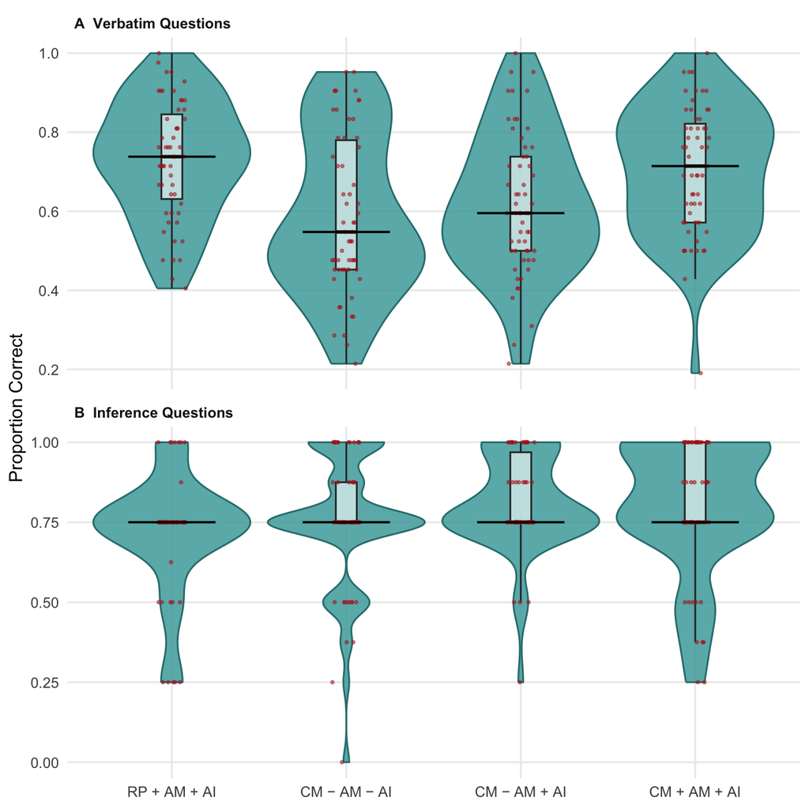

```r
plot_df <- d %>%
  select(cond, verbatim, inference) %>%
  pivot_longer(c(verbatim, inference), names_to = "qtype", values_to = "prop") %>%
  mutate(qtype = factor(ifelse(qtype == "verbatim",
                               "A  Verbatim Questions", "B  Inference Questions"),
                        levels = c("A  Verbatim Questions", "B  Inference Questions")))

ggplot(plot_df, aes(cond, prop)) +
  geom_violin(fill = "#4aa8a8", colour = "#2f7d7d", alpha = 0.85,
              scale = "width", trim = TRUE) +
  geom_boxplot(width = 0.12, outlier.shape = NA, fill = "white", alpha = 0.6) +
  geom_jitter(width = 0.08, height = 0, size = 0.7, alpha = 0.5, colour = "#b22222") +
  stat_summary(fun = median, geom = "crossbar", width = 0.5,
               linewidth = 0.3, colour = "black") +
  facet_wrap(~ qtype, ncol = 1, scales = "free_y") +
  scale_x_discrete(labels = c("RP + AM + AI", "CM − AM − AI",
                              "CM − AM + AI", "CM + AM + AI")) +
  labs(x = NULL, y = "Proportion Correct") +
  theme_minimal(base_size = 13) +
  theme(panel.grid.minor = element_blank(),
        strip.text = element_text(face = "bold", hjust = 0))
```

# 8 Judgments of learning (JoL)

> Paper: *F*(3, 226) = 10.22, *p* < 0.001, η²<sub>p</sub> = 0.12. RP + AM + AI (*M* = 44.18) rated significantly lower than CM − AM − AI (*p* = 0.005), CM − AM + AI (*p* < 0.001), and CM + AM + AI (*p* < 0.001).

```r
m_jol <- aov(JoL ~ cond, data = d)
summary(m_jol)
```

```
             Df Sum Sq Mean Sq F value   Pr(>F)
cond          3   8101  2700.5   10.22 2.44e-06 ***
Residuals   226  59690   264.1
---
Signif. codes:  0 '***' 0.001 '**' 0.01 '*' 0.05 '.' 0.1 ' ' 1
```

```r
cat(sprintf("partial eta-squared = %.3f\n", eta_p(m_jol, "cond")))
```

```
partial eta-squared = 0.120
```

```r
round(TukeyHSD(m_jol)$cond[c("CM-AM-RI-RP+AM+RI",
                             "CM-AM+RI-RP+AM+RI",
                             "CM+AM+RI-RP+AM+RI"), "p adj"], 4)
```

```
CM-AM-RI-RP+AM+RI CM-AM+RI-RP+AM+RI CM+AM+RI-RP+AM+RI
           0.0054            0.0000            0.0000
```

*F* = 10.22, η²<sub>p</sub> = .12 and all three RP-vs-CM post-hoc *p*-values (.005, < .001, < .001) reproduce the paper. Participants in the retrieval-practice condition *predicted* they would remember the least — the classic dissociation between judgments of learning and actual performance under retrieval practice. (The CM − AM − AI cell mean is 54.40 here vs. 54.10 printed in the paper — a trivial discrepancy; the *F* and all other cells match.)